# R Notebook Coursework

# 1 **Introduction**

## 1.1 Motivation for the work below

The main aim of this coursework is to provide insights into bike sharing patterns and features from the raw data that has been made available by Capital Bikeshare. With the idea that results gotten at the end of this coursework, can answer interesting questions related to the features of the sample that we have available to us. But also those outcomes can lead to new questions, which require either more detailed data or more sophisticated methods.

The topic of bike sharing is worth examining, as shared public transport, such as e-cotters and bikes have been becoming more and more popular in recent years. And this trend is likely to continue to do so, as gas prices remain relatively high, tighter emission standards for vehicles are getting passed, and congestion remains a prominent issue, making conventional transport uneconomical to use for personal transportation.

# 2 **Data**

## 2.1 Raw Data

The data used for this report comes from Capital Bikeshare’s trips history data which is publicly available on their website https://ride.capitalbikeshare.com/system-data. The raw data includes two datasets. `trips` gives us information about all the rides that have started between the periods of 1st of January 2019 and 31st of December 2020. And `stations` inform us about all the available bike stations across Capital Bikeshare’s network.

The raw data files include 16 and 17 variables each. Some of those various variables will be utilized, but some won’t and therefore will be removed. As they are either not recorded properly or do not give us insightful information.

## 2.2 Main retained Variables

Here is a brief summary of the main retained variables from both datasets:

- `duration` - duration of a single trip
- `start_date` and `end_date` - when has a trip started and ended
- `start_station_name` and `end_station_name` - from which bike station a trip starts and at which station the trip ends
- `address` - a street location of a bike station
- `start_station_id` and `end_station_id` - same as the above, but instead of names, using the unique numbers of each bike station
- `objectid` - an unique number of an individual bike station
- `bike_number` - an unique number of the bike being used
- `member_casual` - a type of user, indicating whether they have purchased a casual “pass” ride plan, or have become a member by getting a “membership” ride plan
- `rideable_type` - type of bicycle being used
- `start_lat`, `start_lng`, `end_lat`, `end_lng` - the starting and ending coordinates of a single trip
- `latitude`, `longitude` - the coordinates of an individual bike station

## 2.3 Excluded variables

Here is a summary of all the variables that were eliminated from both datasets:

- `ride_id` - unique number of a ride, which was not utilized at any of the steps carried in the report later on, thus removed
- `is_equity` - not made clear what it stands for and was not utilized at any of the steps carried in the report later on, thus removed
- `installed` - whether a station has been installed, but as all were of the status installed, the variable was obsolete and thus removed
- `install_date` and `removal_date` - presumably the installation and removal dates of single stations, but as for all stations those both variables indicate 1st January 1970, the variables were obsolete and thus removed
- `se_anno_cad_data` - not made clear for what it stand, but as it was filled with only NA’s, it was not utilized at any of the steps carried in the report later on, thus removed
- `owner` - indicates who owns the stations, but it was not utilized at any of the steps carried in the report later, thus removed
- `temporary_install` - as none of the stations was a temporary install, this variable was obsolete and thus removed

## 2.4 Creation of new variables

A few additional variables were either modified or added, here is a summary of those:

- `duration` - was modified by calculating the difference between `start_date` and `end_date`, as it previously it was filled with many missing values
- `member_casual` - was modified by standardizing the format for *Members* and *Casual* users
- `start_lat`, `start_lng`, `end_lat`, `end_lng` - were modified, by in filling their missing values, via the dataset `stations`
- `distance_km` - a new variable, that is based on the Haversine formula, calculating the distance in kilometers between the start and end points of a journey, based on `start_lat`, `start_lng`, `end_lat`, `end_lng`

# 3 **Questions**

## 3.1 Question 1

**How has the demand for shared bike riding provided by Capital Bikeshare changed between 2019 and 2020 on a monthly basis?**

- Operationalization: The demand for shared bike riding will be measured by the total number of rides that have occurred during a particular period of time. In the case of *Question 1*, the time period will be each month of either 2019 or 2020.

## 3.2 Question 2

**During the day, are *Casual* users using the services provided by Capital Bikeshare to a greater extent than *Member* users?**

- Operationalization: The utilization variable will be measured by the hours spent on journeys. As this is the only measurement that we have to base the actual use of the service. Further, the journey times will be ordered, depending on which part of the day they have started. As well as by what type of user they have been carried out.

## 3.3 Question 3

**People that opt for an electric bike, can either leave it at a bike station free of charge or leave it at any public bike rack for an additional 2$ charge.** **Is this choice related to the distance between a journey’s start and end points or the duration of it? And has this behavior been consistent over time?**

- Operationalization: To differentiate between which users have been charged an additional 2$, we will look at which journeys made via an electric bike that have no end station, but rather just end coordinates. Based on these findings, we will examine, if this decision has a relation with the duration of the ride in minutes and the distance in kilometers between the start and end points of the journey. It is important to note that we don’t imply any causality.

## 3.4 Question 4

**Is the distance traveled between the start and end bike stations, indicative of the riding plan chosen by a user?**

- Operationalization: The distance between the start and end bike stations will be measured in kilometers. And further, those distances will be grouped depending on the ride plan that users have opted to choose. Measuring the density that each user group represents, based on their distances.

## 3.5 Question 5

**Which are the 5 most popular journeys among Capital Bikashare’s users and how long does it take them on average to complete it?**

- Operationalization: The journey variable will be consisting of a combination between the start and end station of a bike ride. The 5 most popular journeys are going to be chosen based on their frequency. While the average times of completion are going to be measured in hours by a median. With further information about the spread, provided by an interquartile range.

# 4 **Analysis**

## 4.1 Analysis to Question 1

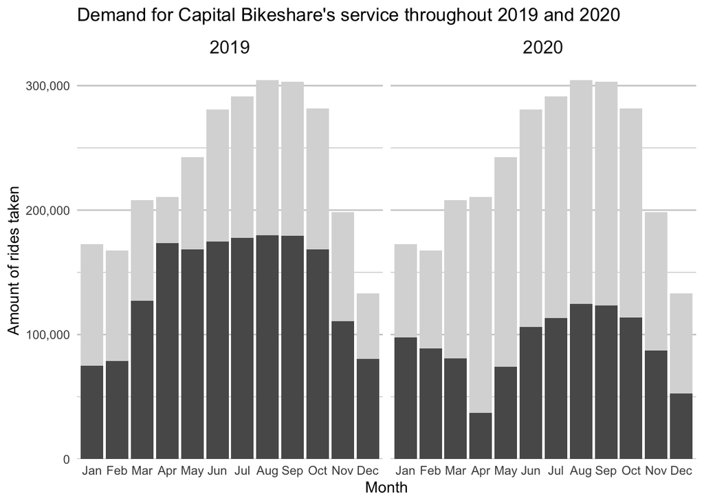

What can be immediately seen from the “Demand for Capital Bikeshare’s service throughout 2019 and 2020” figure is that 2020 has seen far fewer rides taken, relative to 2019. It is interesting to notice that there is a sharp drop in April 2020, after which the demand for the service is not able to catch up to the 2019 figures. This perhaps may be due to COVID-19 measures that have been taking place at that time.

## 4.2 Analysis to Question 2

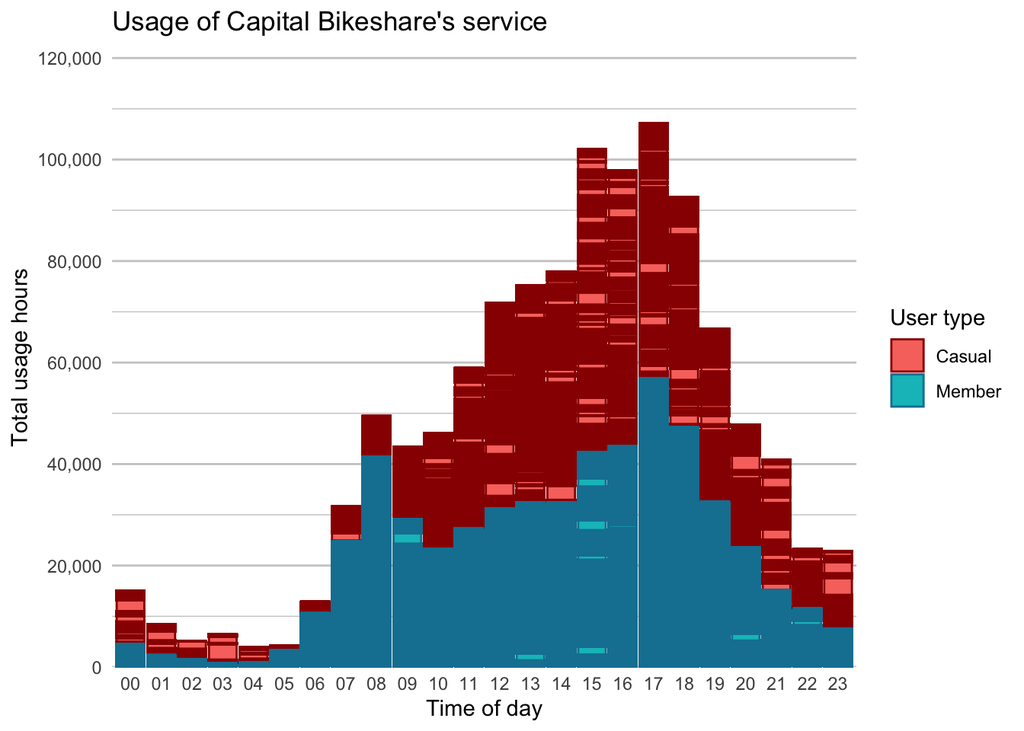

## 4.3 Analysis to Question 3

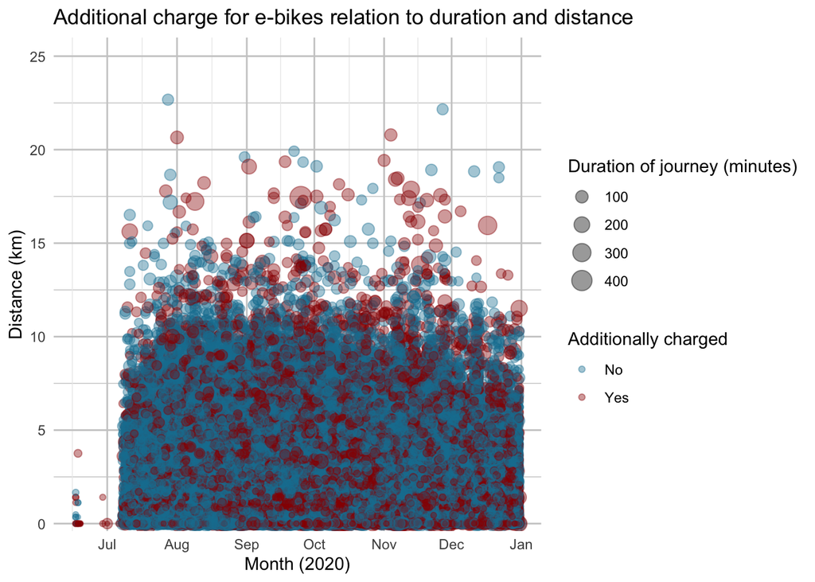

Something interesting about the “Additional charge for e-bikes relation to duration and distance” figure is that the *Month (2020)* scale starts from mid-June. This is the case as e-bikes have been introduced on the 17th of June 2020 and simply previous data does not exist.

## 4.4 Analysis to Question 4

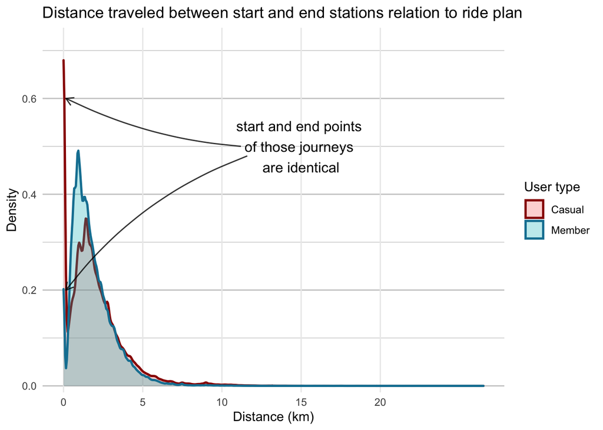

The “Distance traveled between start and end stations relation to ride plan”, shows us that for both user types a popular choice is to return their rented bike to the same station from which they have taken it initially. This is indicated by the both the red and blue line surges along the y axis at the 0 km mark.

Another interesting trend is there is a greater chance a user from *Members* to prefer returning their bike to a different station than their initial one, relative to a *Casual* user. As seen by the area difference of the blue and red peaks between the 0 and 2 kilometers mark roughly.

And finally this graph shows is that the very little chance of the population of users regardless of the type that are willing to make a journey between stations that are more than 5 km apart.

## 4.5 Analysis to Question 5

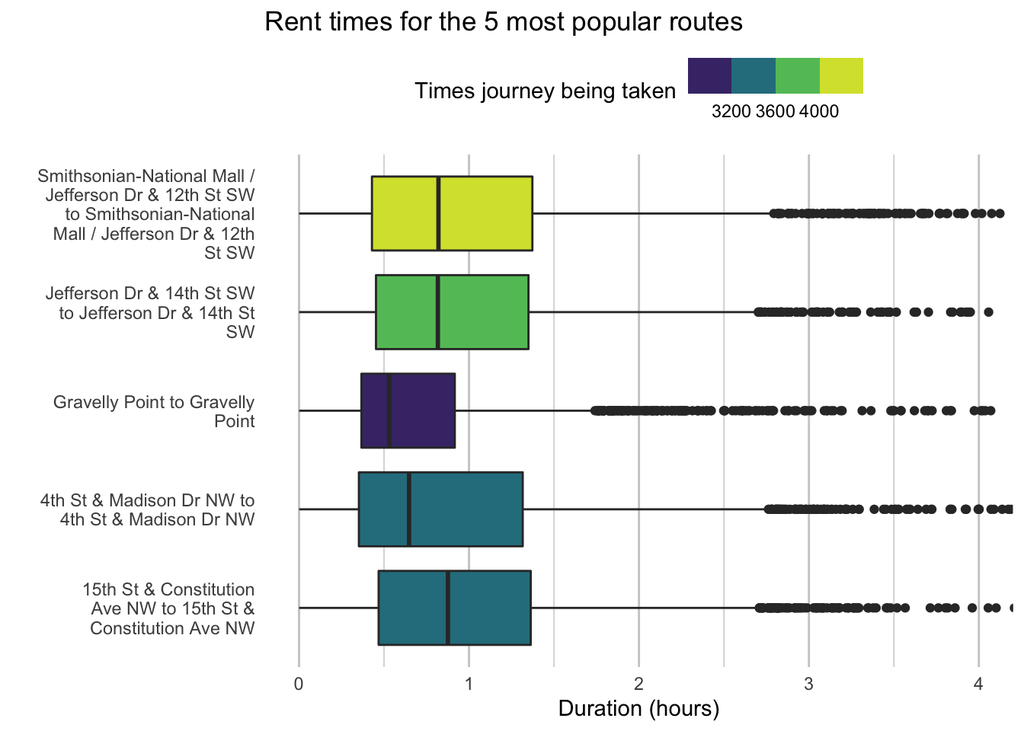

From the figure “Rent times for the 5 most popular routes” it can be seen that all of the 5 most popular journeys, commence and finish at the same bike station. Given the results from Question 4, this does not seem surprising.

Further, it can be seen that half of the users carrying out those journeys, rent out a bike from anywhere 30 minutes to an hour and fifteen minutes. The only exception is the fifth most popular journey, which starts and finishes at Gravelly Point. Fifty percent of the population done it, tend to complete it for anywhere between 20 to 50 minutes.

# 5 **Conclusion**

## 5.1 Summary of results

The results that we have obtained have given us useful insights concerning bike sharing.

## 5.2 Further questions

Given the analysis done above, it will be interesting to see how the duration of the rides has differed with actual traveled distance and not only distance between the initial and finishing bike stations. As this will give us more insight into the potential wear and tear of the bikes. But also could be used for predicting average times for various common travel routes.